# R Notebook

Calculate correlations within each cluster

```r
cluster.gene.corr <- lapply (c(1:3), geneCorr.cluster) %>% setNames(c(1:3))

### add column for sybsystem
clust3.cor.suppMat <- cluster.gene.corr$`3`[order(-rho),] %>%
  left_join(secM_TPM.map[, c("choSymbol", "Subsystem")], by=c("gene"="choSymbol")) %>% dplyr::rename(FDR=padj) %>%
  distinct()
openxlsx::write.xlsx(clust3.cor.suppMat, "Output/Cluster3_cor.xlsx")

## summary of FDR and Rho
lapply(cluster.gene.corr, function(x){summary(x$padj)})
lapply(cluster.gene.corr, function(x){summary(x$rho)})
```

[output not shown]

Note that cluster 3 is the only cluster with significant correlations

```r
sigClust.3 <- sig.clust.cor(clusterID='3', FDR.thresh=0.1, rho.thresh=0.6)
#sigClust.2 <- sig.clust.cor(clusterID='2', FDR.thresh=0.1, rho.thresh=0.6)
#sigClust.1 <- sig.clust.cor(clusterID='1', FDR.thresh=0.1, rho.thresh=0.6)
saveRDS(sigClust.3$sig.plot, "Figures/R_plots/Figure4c.RDS")
```

Plot distribution of protein titer for each cluster

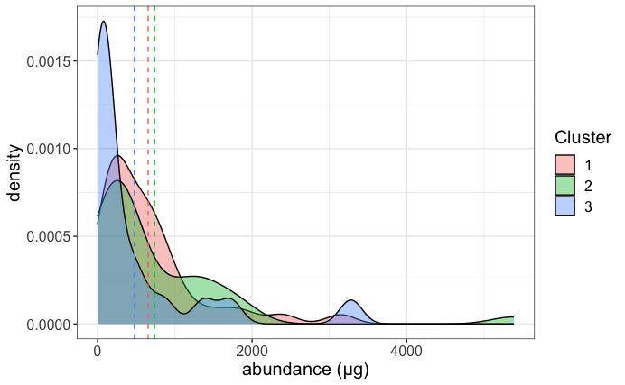

```r
df <- clust.samples[clust.samples$cluster != 4 ,] %>% mutate(cluster2=cluster)
df$cluster2[df$cluster==1] <- 2
df$cluster2[df$cluster==2] <- 1
mu <- plyr::ddply(df, "cluster", summarise, grp.mean=mean(yield))
ggplot(df, aes(x=yield, fill=as.factor(cluster))) + geom_density(alpha=0.4) +
  geom_vline(data=mu, aes(xintercept=grp.mean, color=as.factor(cluster)),linetype="dashed", show.legend = F) +
  labs(fill = "Cluster") + xlab("abundance (μg)") + theme_bw() + theme(text=element_text(size=15))
```

```r
#Note: 2 is 1, 1 is 2
data.clust <- df %>% left_join(CHO96[, c("sample_ID", "amount_microgram")]) %>% data.table()
```

Quantify var explained in Cluster 3 ############################################################

```r
select.genes <- c("Alg12","Derl2", "Rpn1", "Rpn2", "Ddost")
select.samples <- clust.samples$sample_ID[clust.samples$cluster %in% 3]
TPM.subset <- subset(TPM.log.secM, select=select.samples) %>% t() %>% as.data.frame()
response.var <- CHO96[CHO96$sample_ID %in% select.samples, c("sample_ID", "Total.purified.protein_stock1.stock2_microg")]
identical(rownames(TPM.subset), response.var$sample_ID)
```

```
[1] TRUE
```

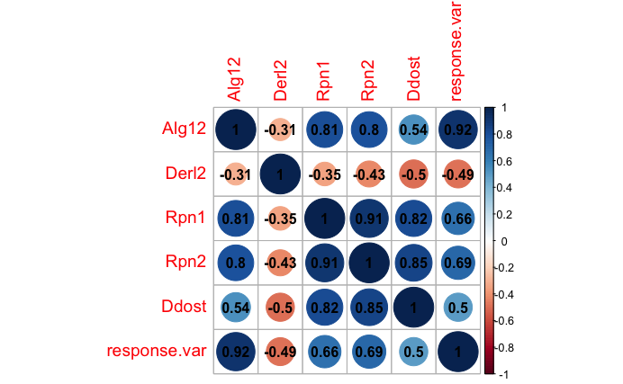

```r
TPM.subset <- subset(TPM.subset, select=select.genes) %>%
  mutate(response.var=log10(response.var$Total.purified.protein_stock1.stock2_microg + 0.001))
corrplot::corrplot(cor(TPM.subset), method="circle", addCoef.col = 1, tl.cex = 1.2)
```

```r
fit.subset <- dplyr::select(TPM.subset, c("Alg12", "Derl2", "response.var"))
fit <- stats::lm(response.var ~ ., data=fit.subset )
summary(fit)
```

```
Call:
stats::lm(formula = response.var ~ ., data = fit.subset)

Residuals:
    Min      1Q  Median      3Q     Max
-1.2409 -0.5571 -0.1265  0.4208  1.3674

Coefficients:
            Estimate Std. Error t value Pr(>|t|)
(Intercept) -10.9147     3.7142  -2.939  0.00918 **
Alg12         3.6204     0.3648   9.924 1.73e-08 ***
Derl2        -1.6425     0.6141  -2.675  0.01600 *
---
Signif. codes:  0 ‘***’ 0.001 ‘**’ 0.01 ‘*’ 0.05 ‘.’ 0.1 ‘ ’ 1

Residual standard error: 0.7195 on 17 degrees of freedom
Multiple R-squared:  0.888, Adjusted R-squared:  0.8748
F-statistic: 67.37 on 2 and 17 DF,  p-value: 8.311e-09
```

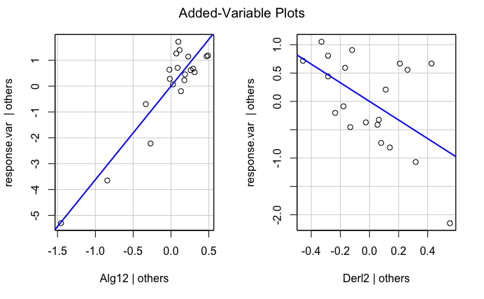

```r
car::avPlots(fit, marginal.scale=F, id=F)
```

Are clusters characterized by specific protein features ############################################################ load protein fetures used in ML

```r
protFeat <- readRDS("Output/protFeatures96.RDS") %>% left_join(clust.samples) #%>% mutate(cluster=as.factor(cluster))
protFeat.all <- readRDS("../ProteinFeatures/Output/Tegel2020_allFeatures.RDS")
protFeat.subset <- protFeat.all$features_allSamples %>%
  right_join(clust.samples, by=c("human_symbol"="gene")) %>%
  dplyr::filter(cluster != 4) %>%
  mutate(cluster=as.factor(cluster))
```

Anova

```r
anova.feat <- dplyr::select(protFeat.subset, "abundance_GTEx_Adipose":cluster)
colnames(anova.feat) <-str_replace(names(anova.feat), "%", "percent")
colnames(anova.feat) <- str_replace(names(anova.feat), "-", "_")
# run anova for ever protein feature
res.anova <- sapply(names(anova.feat)[-219], anova.fxn) %>%
  lapply(function(x) {x$`Pr(>F)`[1]})
summary(unlist(res.anova))
```

```
   Min. 1st Qu.  Median    Mean 3rd Qu.    Max.
0.01649 0.28233 0.48893 0.49764 0.73070 0.96225
```

```r
View(sort(unlist(res.anova)))
```

Note: no defining features in each cluster

Compare secM exp low vs high prod in each cluster ############################################################

two-sided welch test comparing low vs high producers in each cluster

```r
welch.cluster(1, TPM.log.secM, alt="two.sided")[padj <=0.1 ,] %>%
  mutate(LFC=mean.x-mean.y)
```

| gene | pval | mean.x | mean.y | padj | LFC |
| --- | --- | --- | --- | --- | --- |
| LOC100769454 | 3.03108e-08 | -9.965784 | -0.6178545 | 1.62769e-05 | -9.34793 |

```r
welch.cluster(2, TPM.log.secM, alt="two.sided")[padj <=0.1 ,]
```

| gene | pval | mean.x | mean.y | padj |
| --- | --- | --- | --- | --- |

```r
welch.cluster(3, TPM.log.secM, alt="two.sided")[padj <=0.1 ,]
```

| gene | pval | mean.x | mean.y | padj |
| --- | --- | --- | --- | --- |

Look at GPI PTM in Cluster 1

```r
# which rProteins in Cluster 1 contain GPI anchor PTM -- NONE
dplyr::select(protFeat.subset, c("human_symbol", "sequence_PSIM_GPI", "sequence_PTM.detailed_Lipidation__GPI.anchor")) %>%
  left_join(data.clust, by=c("human_symbol"="gene")) %>% na.omit() #%>%View()
```

| human_symbol | sequence_PSIM_GPI | sequence_PTM.detailed_Lipidation__GPI.anchor | cluster | sample_ID | yield | cluster2 | amount_microgram |
| --- | --- | --- | --- | --- | --- | --- | --- |
| PPY | 0 | 0 | 1 | P6975_164 | 88 | 2 | lowest amount |
| FCN2 | 0 | 0 | 2 | P6975_146 | 1445 | 1 | highest amount |
| FGFBP3 | 0 | 0 | 3 | P6975_155 | 49 | 3 | lowest amount |
| EPYC | 0 | 0 | 1 | P6975_139 | 2390 | 2 | highest amount |
| KL | 0 | 0 | 1 | P6975_166 | 93 | 2 | lowest amount |
| PCSK1 | 0 | 0 | 3 | P6975_160 | 81 | 3 | lowest amount |
| FLT3LG | 0 | 0 | 3 | P6975_192 | 0 | 3 | no amount |
| PZP | 0 | 0 | 1 | P6975_140 | 3145 | 2 | highest amount |
| FN1 | 0 | 0 | 2 | P6975_161 | 83 | 1 | lowest amount |
| IL22 | 0 | 0 | 2 | P6975_152 | 1298 | 1 | highest amount |

[output cut: 15 more lines]

```r
# load list of host HCP proteins in CHO [10.1038/srep28547]
GPI.HCP <- openxlsx::read.xlsx("Data/protFeatures/IoscaniJimenez_2016.xlsx", sheet="ST10 - GAG and GPI", startRow=3, colNames=T, check.names=T) %>%
  dplyr::select(c("Entry.Name", "GPI.Anchor")) %>%
  dplyr::filter(GPI.Anchor==1) %>%
  mutate(geneName=gsub("_.*","",Entry.Name)) %>%
  left_join(dplyr::select(list.TPM_pheno_map$CHO.human_map, c("choSymbol", "humanSymbol")), by=c("geneName"="humanSymbol"))
# load other list of GPI anchor proteins from secRecon (need to map to gene names)
CHOmap <- fread("ConversionTable/geneInfo_cho_simple.tsv") %>% # map entrezID to gene name
  mutate(GeneID=as.character(GeneID)) %>%
  # map uniprotID to entrezID
  inner_join(openxlsx::read.xlsx("ConversionTable/CHOProtein.xlsx"), by=c("GeneID"="ENTREZ_GENE"))
PSIM.GPI <- openxlsx::read.xlsx("Data/protFeatures/PSIM_matrix.xlsx", sheet="Chinese hamster") %>%
  filter(GPI==1) %>%
  left_join(dplyr::select(CHOmap, c("UNIPROTKB", "Symbol")), by=c("Entry"="UNIPROTKB"))

# combine
GPI.symbol <- c(GPI.HCP$choSymbol, PSIM.GPI$Symbol) %>% na.exclude()
# extract expression (TPM) of the CHO GPI
TPM.GPI <- dplyr::select(list.TPM_pheno_map$TPM.log, -sds) %>%
  subset(gene %in% GPI.symbol) %>% na.omit() %>% distinct()
#two-sided welch test comparing the expression of GPI-anchor poteins in low vs high producers
exp.data= tibble::column_to_rownames(TPM.GPI, "gene") %>% as.matrix()
welch.cluster(1, exp.data, alt="two.sided")[padj <=0.1 ,] #cluster 1
```

| gene | pval | mean.x | mean.y | padj |
| --- | --- | --- | --- | --- |

```r
welch.cluster(2, exp.data, alt="two.sided")[padj <=0.1 ,] #cluster 2
```

| gene | pval | mean.x | mean.y | padj |
| --- | --- | --- | --- | --- |

```r
welch.cluster(3, exp.data, alt="two.sided")[padj <=0.1 ,] #cluster 3
```

| gene | pval | mean.x | mean.y | padj |
| --- | --- | --- | --- | --- |

Note: No differences in GPI-anchor protiens. The difference in GPI-anchor synthesis gene is prob artifact of being very lowly expressed.